# Assignment 4 - CP

```julia
using Images, ImageView
using Plots, ProgressMeter

plotly()
```

```
Plots.PlotlyBackend()
```

```julia
psnr(I1::Array{Float64,2}, I2::Array{Float64,2}) =  10*log10(1.0/(sum((I1.-I2).^2) / length(I1)))
```

```
psnr (generic function with 1 method)
```

```julia
display_range(v::Float64) = (v + 1.0) * 0.5

# load image and display
img = channelview(load("./cameraman_small.tif"))
img = Float64.(img)

sz = size(img)

display(colorview(Gray, img))
```

# Task 1.

```julia
# compute DFT of the input image
img_f = fft(img)

# Build a spectrum containing only the real part
# of img_f and zeroing the imaginary part, then
# compute the IFFT to build the image in spatial
# domain
img_real_f = real(img_f) .+ fill(0.0im, sz)
img_real = real(ifft(img_real_f))

# Build spectrum containing only the imaginary part
# of img_f and real part 0, then build the image by
# taking the IFFT
img_imag_f = fill(0.0, sz) .+ imag(img_f)*im
img_imag = real(ifft(img_imag_f))

# stitch images together to show them together
out = (hcat(img_real, img_imag))
display(colorview(Gray, out))
```

[output not shown]

# Task 2.

Given an input image f, perform the following tasks:

1. Compute the DFT using MATLAB and reconstruct the original image manually from its cosine and sine DFT coefficients;
2. Compute the DFT manually by projecting it onto cosine and sine basis functions, and use MATLAB to reconstruct the original image using the inverse DFT (IDFT);
3. Compute the DFT manually as done for (b) and use its coefficients to reconstruct the original image manually, as done for (a);
4. Compare the original image with the ones reconstructed in parts (a), (b), and (c), by displaying them side by side. They should be equal.

Performing the DFT and IDFT manually involve computationally expensive operations. Thus, for items (a) to (d), use the reduced‐size version of the cameraman image provided with the assignment. After completing doing these tasks, you will have a good appreciation for the value of the Fast Fourier Transform (FFT) algorithm.

#### Task 2.1.

Compute the DFT using Matlab and reconstruct the original image manually from its cosine and sine DFT coefficients.

```julia
function IDFT(S::Array{Complex{Float64},2})
    # compute the FFT of the image and
    # store its vertical and horizontal size
    M, N = sz[1], sz[2]
    len = M*N

    s = fill(0.0+0.0im, sz)

    # For each frequency (i/M, j/N) we loop over the
    # entire image sampling a complex exponential with
    # this frequency and multiply it by the coefficient
    # computed in the FFT. Notice that this coefficient
    # encodes both the amplitude of the complex exponential
    # and its phase.
    @showprogress for u in 0:(M-1), v in 0:(N-1)

        # frequencies are multiples of the fundamental
        # frequency (1/M, 1/N)
        f_i, f_j = u/M, v/N

        # for each pixel of the image, we sample the base function
        # b(x,y) = exp(2πi(xu/M + yv/N)) at the pixel location (i,j),
        # multiplying it by the (x,y) coefficient computed by the FFT.
        # This coefficient encodes both amplitude and phase of the base
        # function. Notice that as Julia's FFT doesn't normalize the
        # coefficients, we need to do so here dividing by m*n.
        for i in 0:(M-1), j in 0:(N-1)
            s[i+1,j+1] += S[u+1,v+1]/len * exp(im*2π*(i*f_i + j*f_j))
        end
    end

    return s
end

# compute the FFT of the image and
# store its vertical and horizontal size
img_f = fft(img)
img_rec = IDFT(img_f)

# Compare our inverse transform with Julia's IFFT
print("PSNR: ", psnr(real(img_rec), img), " dB")

# We expect the imaginary part of the inverse
# transformation to be zero (as the original
# signal is real). We loop over the elements
# of the inverse transform checking whether
# they're zero.
# Notice that due to numerical error the imaginary
# won't be exactly zero but will rather be
# very close to it. For each element,
# check whether it is sufficiently close
# to zero and then check whether all elements
# are within this range.
ϵ = 0.00000001
print("Is the imaginary part zero everywhere? ", prod( abs.(img_rec |> imag) .< ϵ ), "\n")

display( colorview(Gray, real(img_rec)) )
```

```
Progress: 100%|█████████████████████████████████████████| Time: 0:00:47
```

```
PSNR: 284.03868784963385 dBIs the imaginary part zero everywhere? true
```

### Task 2.2

Compute the DFT manually by projecting it onto cosine and sine basis functions, and use MATLAB to reconstruct the original image using the inverse DFT (IDFT).

```julia
function DFT(s::Array{Float64,2})

    # compute the FFT of the image and
    # store its vertical and horizontal size
    M, N = sz[1], sz[2]
    len = M*N

    S = fill(0.0+0.0im, sz)

    # For each frequency (i/M, j/N), we compute
    # the inner product between the input image
    # and a complex exponential with frequency
    # (i/M, j/N) sampled over the domain of the image
    @showprogress for u in 0:(M-1), v in 0:(N-1)
        # frequencies are multiples of the fundamental
        # frequency (1/M, 1/N)
        f_i, f_j = u/M, v/N

        # inner product between complex exponential
        # and input image
        acc = 0.0
        for i in 0:(M-1), j in 0:(N-1)
            acc += s[i+1,j+1] * exp(-im*2π*(i*f_i + j*f_j))
        end

        S[u+1,v+1] = acc
    end

    return S
end

# compute spectrum with DFT and transform
# back using IFFT
img_f = DFT(img)
img_rec = ifft(img_f)
print("PSNR: ", psnr(img, real(img_rec)), " dB")

display( colorview(Gray, real(img_rec)) )
```

```
Progress:  97%|████████████████████████████████████████ |  ETA: 0:00:01
```

```
PSNR: 268.7089384482345 dB
```

```
Progress: 100%|█████████████████████████████████████████| Time: 0:00:35
```

### Task 2.3

Compute the DFT manually as done for (b) and use its coefficients to reconstruct the original image manually, as done for (a).

```julia
img_rec = DFT(img) |> IDFT

# compute spectrum with DFT and transform
# back using IFFT
print("PSNR: ", psnr(img, real(img_rec)), " dB")

display( colorview(Gray, real(img_rec)) )
```

```
Progress: 100%|█████████████████████████████████████████| Time: 0:00:33
```

```
PSNR: 268.71901795487616 dB
```

```
Progress: 100%|█████████████████████████████████████████| Time: 0:00:46
```

# Task 3.

Explore the role of the DC term (i.e., F(0,0)) by:

### Task 3.1

Compute the DFT of an image f. Then set the DC term to zero. Finally, reconstruct a new image (IDFT) from the resulting spectrum;

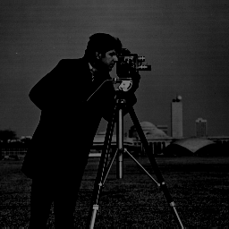

```julia
# load image and display
img = channelview(load("./cameraman.tif"))
img = Float64.(img)
sz = size(img)

# compute fft and set frequency (0,0),
# then compute the inverse transform
img_f = fft(img)
img_f[1,1] = 0.0

img_zero_dc = real(ifft(img_f))

display( colorview(Gray, img_zero_dc) )
```

### Task 3.2

Compute the average intensity level of image f. Subtract such average intensity from all pixel values;

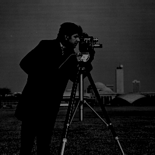

```julia
avg_intensity = sum(img) / length(img)
img_avg = img .- avg_intensity

display( colorview(Gray, img_avg) )
```

### Task 3.3

Compare the results from (a) and (b). What do you get?

```julia
# PSNR of the image with average subtracted
# and DC term zeroed-out
print("PSNR: ", psnr(img_avg, img_zero_dc), " dB")
```

```
PSNR: 317.688300368654 dB
```

# Task 4.

Verify the effect of the fftshift command:

### Task 4.1

Compute the DFT of an image f. Apply the fftshift command to the spectrum of f. Reconstruct an image from the resulting fftshifted spectrum;

[figure not shown]

```julia
# load image and display
img = channelview(load("./cameraman.tif"))
img = Float64.(img)
sz = size(img)

img_f = fft(img) |> fftshift
img_f_shift = real( ifft(img_f) )

display( colorview(Gray, img_f_shift) )
```

### Task 4.2

Compute a new image g(x,y) = (‐1) (x+y) f(x,y) and compare it with the result obtained in (a);

[figure not shown]

```
PSNR: 316.8709983027676 dB
```

```julia
checkerboard = ones(sz)
for i in 1:sz[1], j in 1:sz[2]
    checkerboard[i,j] = (-1)^(i+j)
end

img_checker = img .* checkerboard

print("PSNR: ", psnr(img_f_shift, img_checker), " dB")

display(colorview(Gray, img_checker))
```

### Task 4.3

What will happen in the frequency domain if you apply the fftshift command to image f (in the space domain)?

```julia
# compute spectrum of the fftshifted image
img_shift = fftshift(img)
img_shift_f = fft(img_shift) / (sz[1]*sz[2])

# compute spectrum of the original image
img_f = fft(img) / (sz[1]*sz[2])

# elementwise comparison of the spectrum of
# the shifted image with the original spectrum
# multiplied by the checkerboard pattern
img_shift_f == img_f.*checkerboard
```

```
true
```

# Task 5

Amplitude versus Phase Spectra. Given an input image f, compute its DFT. F(u,v) can be expressed as F(u,v) = |F(u,v)|e^(theta *i). Then reconstruct two separate images (using the IDFT) obtained using: (a) only the amplitude information, i.e, assuming that theta=0: F(u,v) = |F(u,v)| e^(i* theta) = |F(u,v)|; (b) only the phase information, i.e., assuming that |F(u,v)|=1: F(u,v) = e^(i * theta). The images below illustrate the results obtained for the image of the cameraman. As you can see, the phase information is responsible for the structure of the image.

[figure not shown]

```julia
img_f = fft(img)

amplitude = abs.(img_f)
phase = angle.(img_f)

img_amp_f = amplitude .* (cos.(zeros(sz)) + im * sin.(zeros(sz)))
img_amp = real(ifft(img_amp_f))

img_phase_f = 50 .* (cos.(phase) + im*sin.(phase))
img_phase = real(ifft(img_phase_f))

out = hcat(img_amp, img_phase)
display(colorview(Gray, out))
```